# An entire plate tectonic model

Author

Affiliation

Ádám T. Kocsis

GeoZentrum Nordbayern, Friedrich-Alexander-Universität Erlangen-Nürnberg, Loewenichstr. 28, D-91054, Erlangen, Germany

# Load in a complete model

To perform actual reconstructions, we need 1) features that move, and 2) a reconstruction tree (rotation file). The current default model in GPlates 2.3 is a combination model (EarthByte Global Rotation Model) used in [Müller et al. 2019](https://agupubs.onlinelibrary.wiley.com/doi/full/10.1029/2018TC005462), [Young et al. 2019](https://www.sciencedirect.com/science/article/pii/S1674987118301373) and [Cao et al. 2021](https://www.sciencedirect.com/science/article/pii/S1342937X20303051).

These feature collections are included by default among the example files of the GPlates Desktop application. You can use the **Open Feature Collection** menu item to open these. Let’s open the continental polygons (**GeoData/FeatureCollections/ContinentalPolygons/Global_EarthByte_GPlates_PresentDay_ContinentalPolygons.gpmlz**) and the matching rotation file (**GeoData/FeatureCollections/Rotations/Muller2019-Young2019-Cao2020_CombinedRotations.rot**) files! After that you should see a similar image:

[figure not shown]

You can also fill the polygons to make the features more prominent (also, the projection is changed to *Rectangular*):

[figure not shown]

This model is fully linked by default. If you go anywhere in time and start to play the animation, the continents will move, as they should:

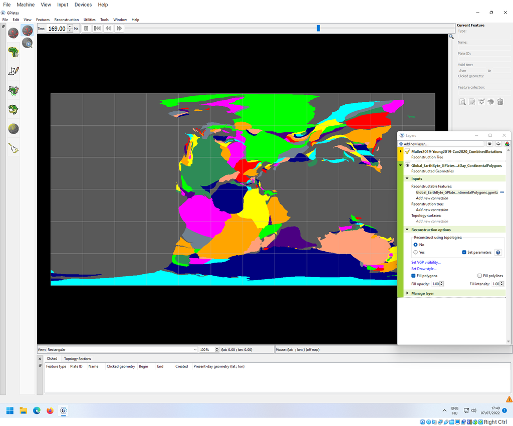

# Configure animation

The animation triggered by the play button can be configured in detail under the **Reconstruction->Configure Animation…** menu item.

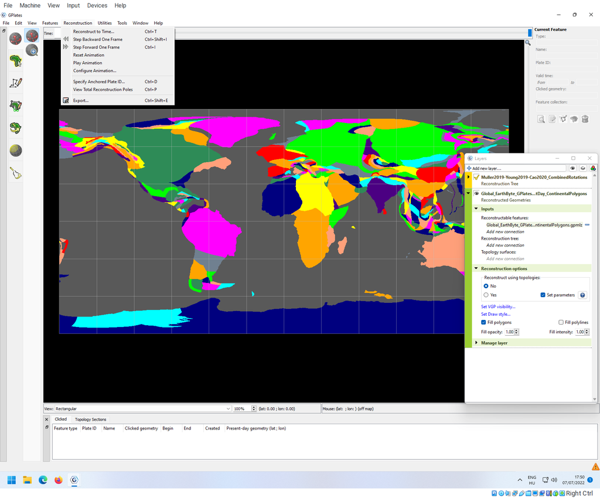

You can set the interval of the animation (**Animation from** and **to**), as well as the increment time passing between frames. You can also set the rate of the rendered frames (**Frames per second**). The configuration below will result in a much smoother, but slower transition:

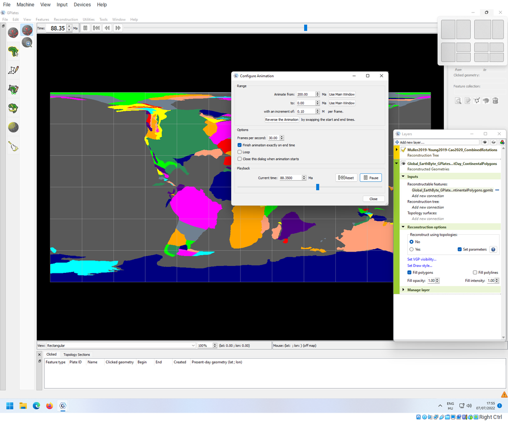

*Note that the speed of the animation will be limited by the processing power of your computer (the images still have to be calculated!).*

# Exporting series of images

Similar to exporting indiviual snapshots, you can also export a series of images. For this, you need to go to the **Reconstruction -> Export** menu item.

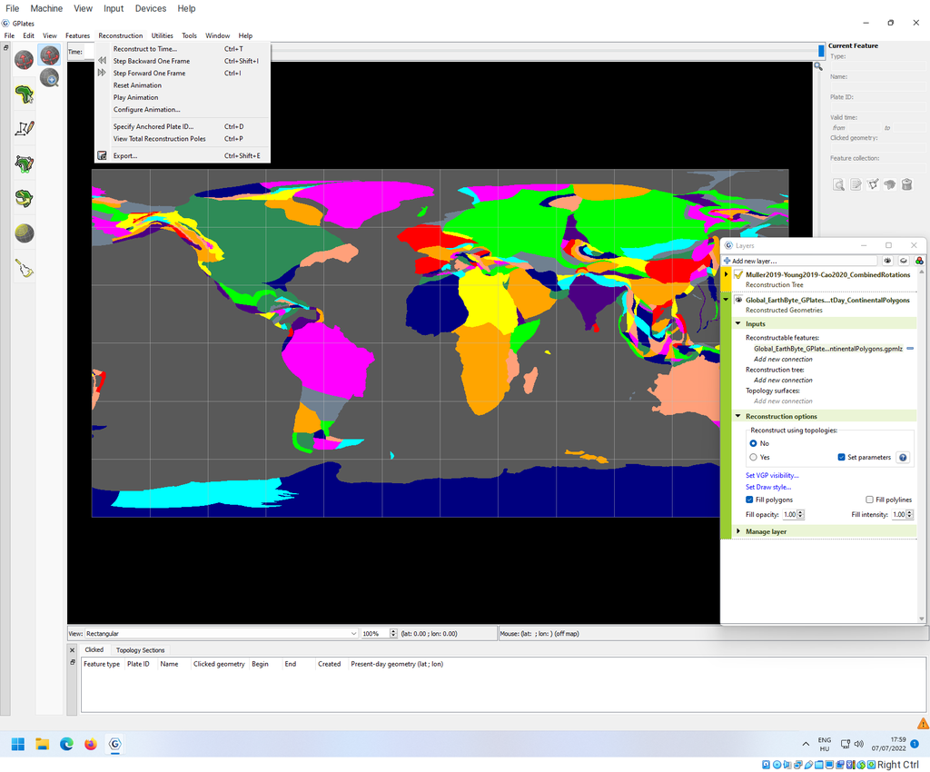

By default, the window opens up with *Export Time Sequence of Snapshots* selected.

[figure not shown]

For the sake of this exercise, I have selected to export png images. You can configure the sequence (from, to and increment) similar to how you configured the animations. In this case, a new image will be drawn for every 500ka between 200Ma and 0Ma.

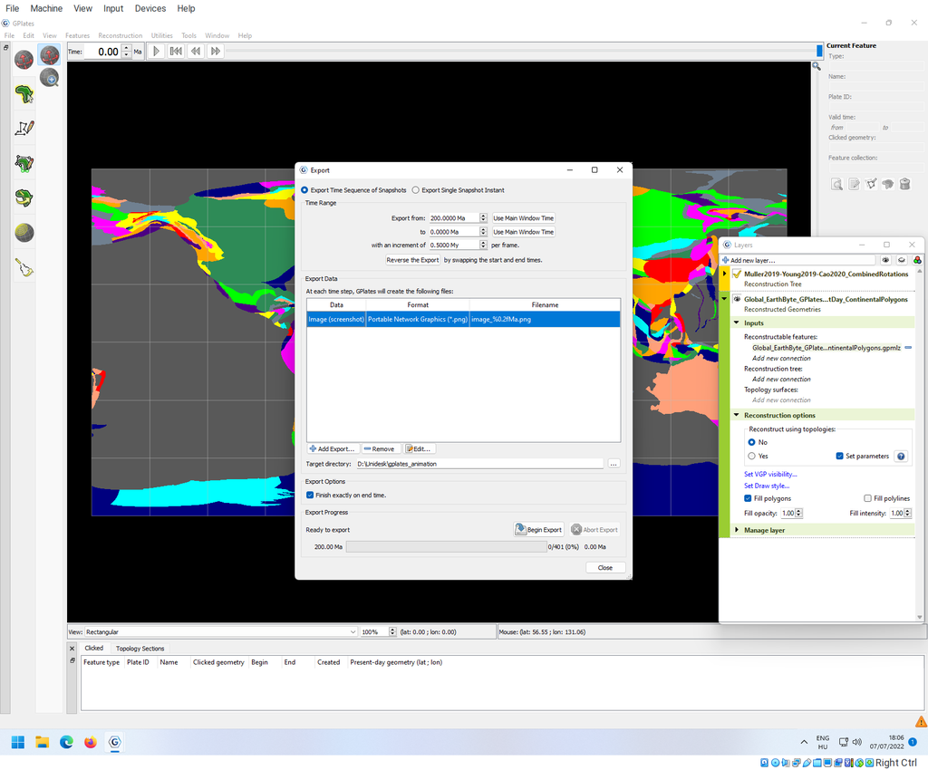

Click on **Begin Export** to save the files.